# “La ardilla roja”

Elsa Sendra Felipe

2023-03-09

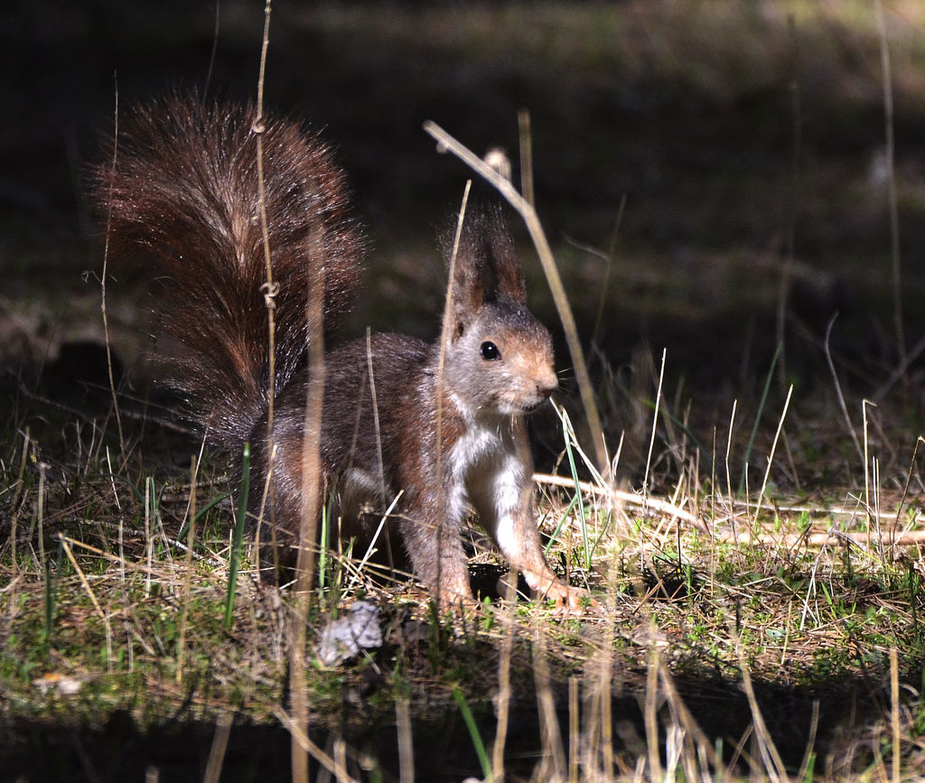

Figura 1.Individuo de ardilla roja (*Sciurus vulgaris*) en un pinar de Granada. Fotografía propia.

# Breve descripción

### Evolución de la especie

Esta especie ha sufrido una evolución positiva de su distribución en la provincia de Granada (Andalucía, España) en los últimos años.

### Metodología de muestreo

En adición al conteo de ejemplares vistos o el conteo de nidos, algunos autores (Lurz et al., 2005) sugieren que el método de detección de ardillas a través de piñas roídas en pinares mediterráneos puede ser un buen método para obtener presencia/ausencia de esta especie en zonas determinadas, encontrándose en algunos estudios este rastro de alimentación en los primeros cinco minutos de muestreo (Moleón & Gil-Sánchez, 2003).

### Rastros de alimentación

En orden a discernir los restos de piñas roídas por ardilla de las roídas por otras especies, se tuvo en cuenta, además del conjunto de rastros y su localización (Tabla 1), el aspecto deshilachado de las piñas roídas. Las ardillas tienen la fuerza suficiente para arrancar las brácteas sin cortarlas royendo, como hacen otros roedores, donde el aspecto de la piña sería mucho más uniforme y de corte más apurado. En cuanto al flujo de trabajo del presente proyecto, se seguirá lo especificado en la Figura 2.

Tabla 1. Datos de los muestreos realizados.

| Zona | Esp | Piñas | Altura |
| --- | --- | --- | --- |
| AG | Ph | 102 | 900 |
| EJ | Pn | 123 | 1000 |
| OI | Ps | 58 | 1100 |

Con una altitud media de

[output not shown]

metros, se han encontrado un total de

```
## [1] 283
```

piñas, habiendo una media de

[output not shown]

piñas por parcela.

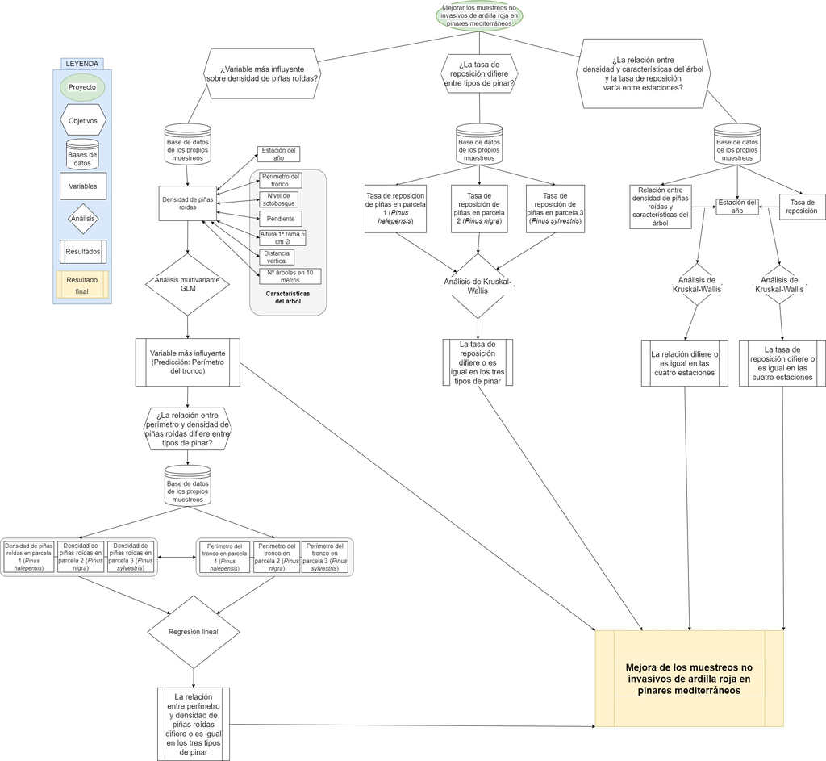

Figura 2. Diagrama de flujo realizado en la página web Diagrams.io

### Bibliografía

- Piqué, J., Rodríguez-Teijeiro, J. D. (2012). L’esquirol vermell (Sciurus vulgaris). Part primera. Comportament i història natural. Picot Negre, Desembre, nº 20: 11-14.
- Lurz W.W., Gurnell J., Magris L., 2005. Sciurus vulgaris. Mammalian Species 769: 1–10.
- Moleón, M. & Gil-Sánchez, J. M. (2003). Distribución, vías de introducción, expansión y apuntes sobre la taxonomía de las poblaciones de ardilla roja (Sciurus vulgaris) en la provincia de Granada (SE de España). Acta Granatense 2, 45-54.